# MDS and PCA worked by hand

**Purpose.** Do both analyses by hand before running any software, so that the output of PCAone and PCAngsd later is not a black box. Every PCA exercise that follows assumes you have seen what the tools are actually computing.

**What you will do**

- compute pairwise distances and run multidimensional scaling with `cmdscale`
- normalise a genotype matrix and take its singular value decomposition by hand
- reconstruct the data from the decomposition, and see what is lost by keeping only the first components
- get the same principal components from the covariance matrix, and relate its eigenvalues to the singular values
- work out how much of the variation each PC captures

**The data.** None — the genotype matrix is **typed in below**: 5 individuals at 7 SNPs, the same small example used in the lecture slides. It is small enough that every number can be checked by hand, which is the point.

**After this** go on to one of the exercises that runs the method on real data: called genotypes or low depth sequencing.

## Simple example of PCA and MDS

First let's try to perform PCA and MDS on the small matrix from the slides. The below code will input the genotypes into R.

```
#read in data from slides
G <-matrix(c(1,0,2,0,2,0,2,1,1,1,0,1,0,2,1,2,1,1,1,1,1,0,1,0,2,0,1,1,0,2,1,2,0,1,0),5,by=T,
           dimnames=list(paste0("IND",1:5),paste0("SNP",1:7)))
nInd <- nrow(G)

print(G)
```

```
     SNP1 SNP2 SNP3 SNP4 SNP5 SNP6 SNP7
IND1    1    0    2    0    2    0    2
IND2    1    1    1    0    1    0    2
IND3    1    2    1    1    1    1    1
IND4    0    1    0    2    0    1    1
IND5    0    2    1    2    0    1    0
```

## MDS

Let's try to do MDS. First let's calculate the distance. The simple distance measure as seen in the slides is called a Manhattan distance.

```
## continue in R
D<-dist(G,upper=T,diag=T,method="manh")
D
```

```
     IND1 IND2 IND3 IND4 IND5
IND1    0    3    7   10   11
IND2    3    0    4    7    8
IND3    7    4    0    5    4
IND4   10    7    5    0    3
IND5   11    8    4    3    0
```

- How many dimensions are used to represent the distances?

Now let's reduce the number of dimension to 2 using MDS and plot the results:

```
k2<-cmdscale(D,k=2)

cat("\n Dimension reduction to two dimensions")
k2
cat("\n original Distance between individuals:")
org <- dist(G,upper=T,diag=T,method="manha")
org

cat("\n Distance between individuals in from the MDS:")
round(D_k2<- dist(k2,upper=T,diag=T),2)
```

```
 Dimension reduction to two dimensions
```

A matrix: 5 × 2 of type dbl

| IND1 | 6.114866 | 0.2977272 |
| --- | --- | --- |
| IND2 | 3.077094 | 0.2402932 |
| IND3 | -0.621230 | -1.7944048 |
| IND4 | -3.723118 | 2.1483083 |
| IND5 | -4.847612 | -0.8919238 |

```
 original Distance between individuals:
```

```
     IND1 IND2 IND3 IND4 IND5
IND1    0    3    7   10   11
IND2    3    0    4    7    8
IND3    7    4    0    5    4
IND4   10    7    5    0    3
IND5   11    8    4    3    0
```

```
 Distance between individuals in from the MDS:
```

```
      IND1  IND2  IND3  IND4  IND5
IND1  0.00  3.04  7.05 10.01 11.03
IND2  3.04  0.00  4.22  7.06  8.01
IND3  7.05  4.22  0.00  5.02  4.32
IND4 10.01  7.06  5.02  0.00  3.24
IND5 11.03  8.01  4.32  3.24  0.00
```

```
#plot the results
 plot(k2,pch=16,cex=3,col=1:5+1,ylab="distance 2th dimension",
      xlab="distance 1. dimension",main="Multiple dimension scaling (MDS)")
 points(k2,pch=as.character(1:5))
```

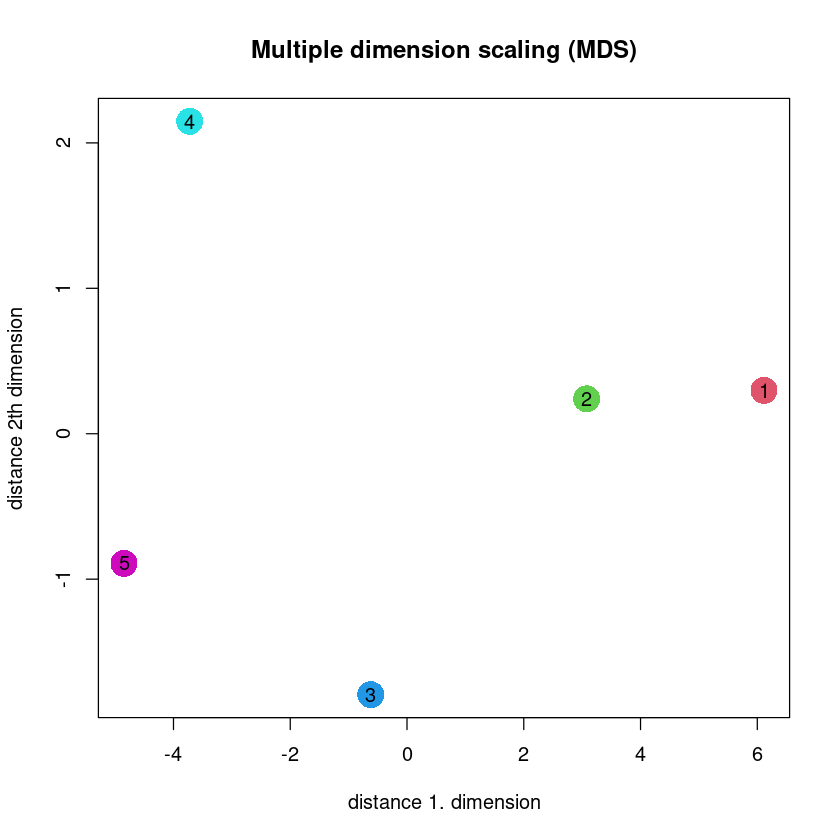

**Questions**

- Compare the plotted distances with the original pairwise distances. What has been lost?
- MDS placed 5 individuals in 2 dimensions. How many dimensions would be needed to represent all the distances exactly?
- Can you find any difference in the pairwise distances from the plot and the original pairwise distances?.

## PCA

First let's try to perform PCA directy on the normalized genotypes without calculating the covariance matrix

- Why do we normalize the genotypes?

```
#first normalize the data so that the mean and variance is the same for each SNP
  normalize <- function(x){
    nInd <- nrow(x)
    avg <- colMeans(x)
    M <- x - rep(colMeans(x),each=nInd)
    M <- M/sqrt(2*rep(avg/2*(1-avg/2),each=nInd))
    M
 }
print(G)
 M <- normalize(G)
print(M)
cat("Dimension of M")
dim(M)

 svd <- svd(M)
 ## print the decomposition for M=SDV
 ## u is the eigenvectors
 ## d is eigen values
 print(svd)
```

```
     SNP1 SNP2 SNP3 SNP4 SNP5 SNP6 SNP7
IND1    1    0    2    0    2    0    2
IND2    1    1    1    0    1    0    2
IND3    1    2    1    1    1    1    1
IND4    0    1    0    2    0    1    1
IND5    0    2    1    2    0    1    0
           SNP1       SNP2      SNP3      SNP4       SNP5       SNP6       SNP7
IND1  0.6172134 -1.7320508  1.414214 -1.414214  1.7320508 -0.9258201  1.1547005
IND2  0.6172134 -0.2886751  0.000000 -1.414214  0.2886751 -0.9258201  1.1547005
IND3  0.6172134  1.1547005  0.000000  0.000000  0.2886751  0.6172134 -0.2886751
IND4 -0.9258201 -0.2886751 -1.414214  1.414214 -1.1547005  0.6172134 -0.2886751
IND5 -0.9258201  1.1547005  0.000000  1.414214 -1.1547005  0.6172134 -1.7320508
Dimension of M
```

1. 5

2. 7

```
$d
[1] 5.261803e+00 2.053667e+00 1.566501e+00 9.253336e-01 3.748163e-16

$u
            [,1]        [,2]       [,3]       [,4]      [,5]
[1,]  0.64933919  0.09424370 -0.5834128 -0.1706056 0.4472136
[2,]  0.35989402  0.07538164  0.5914222  0.5612608 0.4472136
[3,] -0.07799398 -0.60916998  0.3226848 -0.5645382 0.4472136
[4,] -0.39798601  0.72856890  0.1094660 -0.3143433 0.4472136
[5,] -0.53325321 -0.28902426 -0.4401602  0.4882264 0.4472136

$v
           [,1]       [,2]         [,3]       [,4]        [,5]
[1,]  0.2730876 -0.3302541  0.325740175 -0.2899575  0.35747149
[2,] -0.3457940 -0.6975136  0.429315165  0.1470835 -0.03356696
[3,]  0.2814894 -0.4368143 -0.625520546  0.2196783  0.50269419
[4,] -0.5215403  0.1858741 -0.305776626 -0.3312989  0.32151510
[5,]  0.4335716 -0.2426873 -0.232855131 -0.5373485 -0.52610467
[6,] -0.2959595 -0.1274489 -0.007889476 -0.6514342  0.16605338
[7,]  0.4231225  0.3223520  0.412944032 -0.1521959  0.45897074
```

**Questions**

```
##make a diagonal matrix with the eigenvalues
SIGMA <-  diag(svd$d)
print(SIGMA)
## using the matrixes from the decomposition we can undo the transformation of our normalized genotypes
M2 <- svd$u%*%SIGMA%*%t(svd$v)
cat("Original normalized genotypes (M):")
round(M,3)
cat("Reconstructed normalized genotypes(M2):")
round(M2,3)
```

```
         [,1]     [,2]     [,3]      [,4]         [,5]
[1,] 5.261803 0.000000 0.000000 0.0000000 0.000000e+00
[2,] 0.000000 2.053667 0.000000 0.0000000 0.000000e+00
[3,] 0.000000 0.000000 1.566501 0.0000000 0.000000e+00
[4,] 0.000000 0.000000 0.000000 0.9253336 0.000000e+00
[5,] 0.000000 0.000000 0.000000 0.0000000 3.748163e-16
Original normalized genotypes (M):
```

A matrix: 5 × 7 of type dbl

|  | SNP1 | SNP2 | SNP3 | SNP4 | SNP5 | SNP6 | SNP7 |
| --- | --- | --- | --- | --- | --- | --- | --- |
| IND1 | 0.617 | -1.732 | 1.414 | -1.414 | 1.732 | -0.926 | 1.155 |
| IND2 | 0.617 | -0.289 | 0.000 | -1.414 | 0.289 | -0.926 | 1.155 |
| IND3 | 0.617 | 1.155 | 0.000 | 0.000 | 0.289 | 0.617 | -0.289 |
| IND4 | -0.926 | -0.289 | -1.414 | 1.414 | -1.155 | 0.617 | -0.289 |
| IND5 | -0.926 | 1.155 | 0.000 | 1.414 | -1.155 | 0.617 | -1.732 |

```
Reconstructed normalized genotypes(M2):
```

A matrix: 5 × 7 of type dbl

| 0.617 | -1.732 | 1.414 | -1.414 | 1.732 | -0.926 | 1.155 |
| --- | --- | --- | --- | --- | --- | --- |
| 0.617 | -0.289 | 0.000 | -1.414 | 0.289 | -0.926 | 1.155 |
| 0.617 | 1.155 | 0.000 | 0.000 | 0.289 | 0.617 | -0.289 |
| -0.926 | -0.289 | -1.414 | 1.414 | -1.155 | 0.617 | -0.289 |
| -0.926 | 1.155 | 0.000 | 1.414 | -1.155 | 0.617 | -1.732 |

**Question**

- The reconstruction used all the singular values. What would you keep if you wanted only the first two principal components, and what would be lost?
- Did the reconstruction of the normalized genotypes work?
- Would you be able to reconstruct the unnormalized (raw) genotypes?

Now try performing PCA based on the covariance matrix instead. To do so we first calculate the covariance matrix:

```
## calculate the covariance matrix
C <- M %*% t(M)
 print(C)
```

```
          IND1       IND2       IND3       IND4      IND5
IND1 12.571429  5.5714286 -2.0238095 -6.9761905 -9.142857
IND2  5.571429  4.7380952 -0.7738095 -3.7261905 -5.809524
IND3 -2.023810 -0.7738095  2.2619048 -0.7738095  1.309524
IND4 -6.976190 -3.7261905 -0.7738095  6.7380952  4.738095
IND5 -9.142857 -5.8095238  1.3095238  4.7380952  8.904762
```

**Question**

The covariance matrix also shows the relationship between each individuals with the most similar individuals having a high positive value while the most distant individuals having a negativ value. However, unlike the euclidian distance the diagonal is not zero but instead is it related to the diversity within each individual.

Now let's try to do PCA on this covariance matrix instead

```
## then perform the PCA by singular value decomposition
 e <- eigen(C)

 ## print first PC
cat("First pricipal component:")
 print(e$vectors[,1])
 ## print first PC
cat("Eigenvalues:")
 print(round(e$values,4))
 ##plot 2 first PC. for the 5 individuals
 plot(e$vectors[,1:2],pch=16,cex=3,col=1:5+1,ylab="2. PC",
      xlab="1. PC",main="Principle component analysis (PCA)")
 points(e$vectors[,1:2],pch=as.character(1:5))
```

```
First pricipal component:[1] -0.64933919 -0.35989402  0.07799398  0.39798601  0.53325321
Eigenvalues:[1] 27.6866  4.2175  2.4539  0.8562  0.0000
```

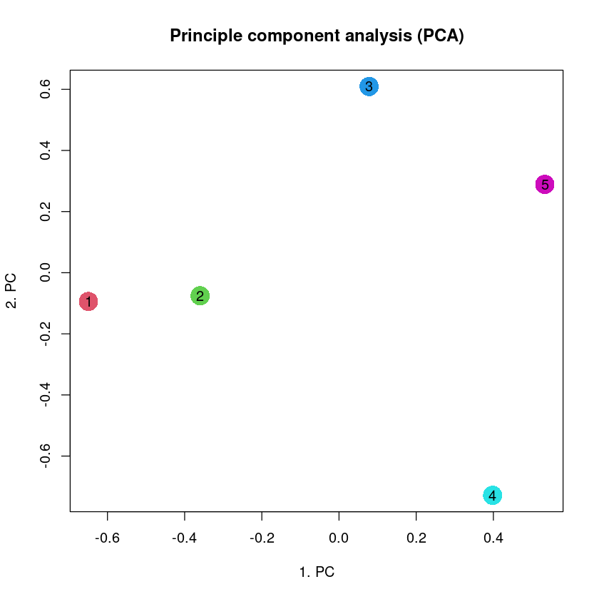

- Do you get the same results using the covariance matrix as using the normalized genotypes directly?
- Compare the two plots (MDS vs. PCA). Are the capturing the same thing?

Bonus information:

Unlike MDS, PCA will not remove information, so you are actually able to reconstruct your covariance matrix from the principal components.

```
##continue in R
##make a diagonal matrix with the eigenvalues
SIGMA <- diag(e$value)

## transform the PC back to the original data
## using matrix multiplication V SIGMA Vt
out <- e$vectors %*% SIGMA %*% t(e$vectors)
cat("Reconstructed covariance:")
print(out)
cat("Original covariance:")
print(C)
#close R after you are done
```

```
Reconstructed covariance:          [,1]       [,2]       [,3]       [,4]      [,5]
[1,] 12.571429  5.5714286 -2.0238095 -6.9761905 -9.142857
[2,]  5.571429  4.7380952 -0.7738095 -3.7261905 -5.809524
[3,] -2.023810 -0.7738095  2.2619048 -0.7738095  1.309524
[4,] -6.976190 -3.7261905 -0.7738095  6.7380952  4.738095
[5,] -9.142857 -5.8095238  1.3095238  4.7380952  8.904762
Original covariance:          IND1       IND2       IND3       IND4      IND5
IND1 12.571429  5.5714286 -2.0238095 -6.9761905 -9.142857
IND2  5.571429  4.7380952 -0.7738095 -3.7261905 -5.809524
IND3 -2.023810 -0.7738095  2.2619048 -0.7738095  1.309524
IND4 -6.976190 -3.7261905 -0.7738095  6.7380952  4.738095
IND5 -9.142857 -5.8095238  1.3095238  4.7380952  8.904762
```

Try to also compare the eigenvalues from the decomposition of the normalized genotypes and from the covariance matrix

```
cat("Eigenvalues of the covariance matrix:")
 print(round(e$values,4))

cat("Singular values from the normalized genotypes:")
 print(round(svd$d,4))
```

```
Eigenvalues of the covariance matrix:[1] 27.6866  4.2175  2.4539  0.8562  0.0000
Singular values from the normalized genotypes:[1] 5.2618 2.0537 1.5665 0.9253 0.0000
```

**Question**

- Compare the eigenvalues of the covariance matrix with the singular values of the normalised genotypes. What is the relationship? (try squaring one of them)

### Run the cell below to take the quiz

```
from jupyterquiz import display_quiz

display_quiz("https://raw.githubusercontent.com/popgenDK/courses/main/current_exercises/pca/quiz/pcaone1.json")
```

- What is the relationship? (hint: try to square one of them by changing the above code)

## How much of the variation does each PC capture?

[figure not shown]

[figure not shown]

Let us calculate it both ways and check that they agree.

```
## the eigenvalues of the covariance matrix
lambda <- e$values

## the proportion of the variance that each PC explains
varExp <- lambda / sum(lambda)

cat("variance explained by each PC, from the eigenvalues (%):\n")
print(round(100 * varExp, 2))

## the same numbers from the singular values of the normalized genotypes
varExpSVD <- svd$d^2 / sum(svd$d^2)
cat("\nvariance explained by each PC, from the singular values (%):\n")
print(round(100 * varExpSVD, 2))

## a scree plot
barplot(100 * varExp, names = paste0("PC", seq_along(varExp)), col = "steelblue",
        ylab = "variance explained (%)", main = "Scree plot")
```

```
variance explained by each PC, from the eigenvalues (%):
[1] 78.62 11.98  6.97  2.43  0.00

variance explained by each PC, from the singular values (%):
[1] 78.62 11.98  6.97  2.43  0.00
```

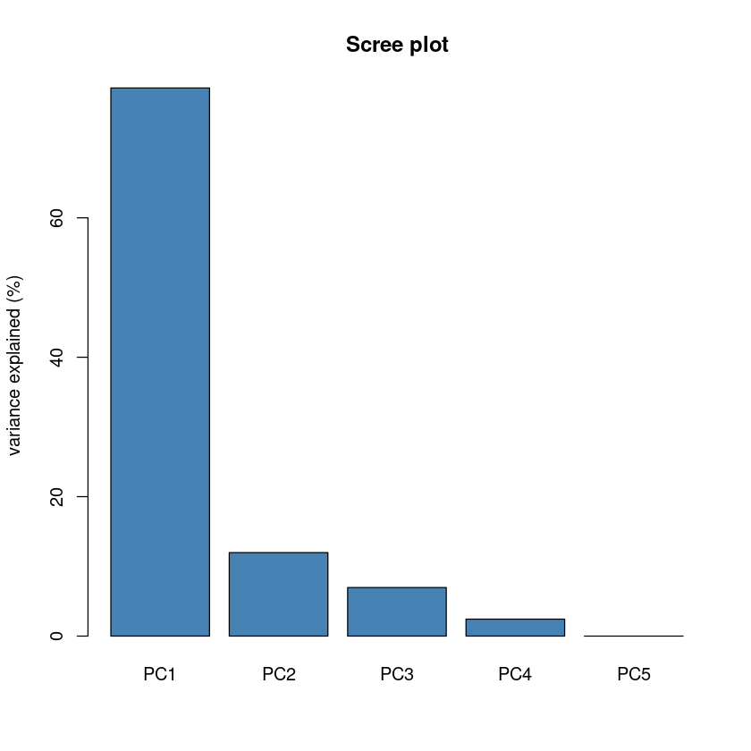

- How much of the variation do PC1 and PC2 together explain? That is the number you should put on the axes when you plot a PCA.
- Why do the eigenvalues and the singular values give exactly the same percentages?
- The last value is zero. Why can 5 individuals never have more than 4 informative PCs? (hint: we subtracted the mean of each SNP before the decomposition)
- Look at the scree plot. If you only knew the eigenvalues and not the populations, how many PCs would you say are worth looking at?
- Would the percentages change if we had not normalized the genotypes first?